# Implémentation d'un filtre de Kalman

## I - Introduction

### I.a - Objectif

Dans le cadre du projet Unirail, qui consiste à commander le fonctionnement de trois trains en parallèle sur la maquette unirail, nous avons pour objectif de réaliser un filtre de Kalman pour obtenir la position du train dans un tronçon. Le filtre se fera en fusionnant les données du train reçue via odométrie et capteur Marvelmind embarqué. Le train implémentera à terme directement le filtre, tournant sur une carte Raspberry Pi.

Dans ce notebook, on détaillera plus précisement les phases d'implémentation du filtre, puis on simulera son fonctionnement grâce à un jeu de données obtenu sur le parcours d'un train.

### I.b - L'infrastructure

L'infrastructure est une maquette de réseau ferroviaire de 4 mètres par 6 mètres. Les différentes parties de l'infrastructure sont divisées en tronçons de 150 centimètres.

### I.c - Théorie du filtre de Kalman

Le filtre de Kalman est un algorithme de filtrage qui permet d'estimer l'état caché d'un système à partir de mesures bruitées. Pour un système linéaire discret, les équations du filtre de Kalman sont les suivantes :

```
Équation de prédiction de l'état :
```

$$\hat{x}_k^- = A\hat{x}_{k-1} + Bu_{k-1}$$

où $\hat{x}_k^-$ est l'estimation de l'état à l'instant $k$ avant la mise à jour de la mesure, $A$ est la matrice de transition d'état, $\hat{x}_{k-1}$ est l'estimation de l'état à l'instant $k-1$, $B$ est la matrice d'entrée de commande et $u_{k-1}$ est l'entrée de commande à l'instant $k-1$.

```
Équation de prédiction de la covariance d'erreur :
```

$$P_k^- = AP_{k-1}A^T + Q$$

où $P_k^-$ est la covariance d'erreur de l'estimation à l'instant $k$ avant la mise à jour de la mesure et $Q$ est la covariance de bruit de processus.

```
Équation de mise à jour de l'estimation de l'état :
```

$$\hat{x}_k = \hat{x}_k^- + K_k(y_k - H\hat{x}_k^-)$$

où $\hat{x}_k$ est l'estimation de l'état à l'instant $k$ après la mise à jour de la mesure, $K_k$ est la matrice de gain de Kalman à l'instant $k$, $y_k$ est la mesure bruitée à l'instant $k$ et $H$ est la matrice de mesure.

```
Équation de mise à jour de la covariance d'erreur :
```

$$P_k = (I - K_kH)P_k^-$$

où $P_k$ est la covariance d'erreur de l'estimation à l'instant $k$ après la mise à jour de la mesure.

La matrice de gain de Kalman $K_k$ est calculée comme suit :

$$K_k = P_k^-H^T(HP_k^-H^T + R)^{-1}$$

où $R$ est la covariance de bruit de mesure.

Le filtre de Kalman peut être utilisé pour estimer l'état d'un système en temps réel en utilisant des mesures bruitées. Les performances du filtre dépendent de la qualité des mesures et des modèles utilisés pour décrire le système et le bruit.

### I.d - Import des librairies

```python
import matplotlib.pyplot as plt
import numpy as np
from scipy import signal
```

## II - Etudes préliminaires

### II.a - Modélisation et dynamique du système

Après une analyse du train face à un échelon en vitesse de 40 cm/s, on a pu le modéliser respectant une dynamique du second ordre et ayant une fonction de transfert:

La fonction de transfert de ce système du second ordre peut être écrite sous la forme suivante en utilisant la notation de Laplace :

L'équation différentielle associée à cette fonction de transfert peut être écrite sous la forme suivante en utilisant la notation de dérivation de Leibniz :

$$\frac{d^2x}{dt^2} + 27.43\frac{dx}{dt} + 62.39x = 62.11u$$

Où $x$ est la position du train et $u$ est la consigne en vitesse.

```python
w_n = 5.14
k = 26.28
xi = (1/(2*w_n))*12.87
```

Voici la dynamique du système:

$$\frac{dx}{dt} = Ax + Bu$$

Et la mesure de son état par les capteurs marvelmind et d'odométrie.

$$ y = Hx$$

Avec: $$ x = \begin{bmatrix} r \\ v \end{bmatrix}$$

$$ A = \begin{pmatrix} 0 & 1 \\ -\omega_n^2 & -2\xi\omega_n \end{pmatrix} $$$$ B = \begin{pmatrix} 0 \\ \omega_n^2 k \end{pmatrix} $$$$ H = \begin{pmatrix} 1 & 0 \\ 1 & 0 \end{pmatrix} $$

```python
A = np.array([[0,1], [-np.power(w_n,2), -2*xi*w_n ]])
B = np.array([[0], [np.power(w_n,2)*k]])
H = np.array([[1,0],[1,0]]) #On obtient deux données via Marvelmind et Odométrie
D = 0
```

### II.b - Etude des capteurs

#### II.b.1 - Marvelmind

Les capteurs utilisés pour obtenir la position du train sont un capteur d'odométrie et un capteur Marvelmind. Afin de mettre en place le filtre on doit obtenir leur variance.

On étudie tout d'abord le Marvelmind. Afin de calculer sa variance, on a pris un jeu de données donnant la position du train lorsque celui-ci est fixe. A partir de ces données, on pourra estimer la variance du capteur. De plus, sa datasheet nous indique une précision de l'ordre de +-2cm, ce qui devrait correspondre à l'ordre de grandeur de variance obtenu.

Les données reçues correspondent à trois coordonnées dans l'espace exprimées en mètres, et à un instant t exprimé en millisecondes. On fait ici un parsing de ces données pour les récupérer dans des listes python, avec des distances en centimètres.

```python
f = open("./data/variance_marvelmind.txt", "r") # Lecture du document et mise sous forme de matrice
lines=f.readlines()

X = []
Y = []
Z = []
T = []
t_0 = int(lines[0].split(',')[5].strip().split(': ')[2])
count_lines = 0
for line in lines:

    parts = line.split(',')
    x_val = float(parts[1].strip().split(': ')[1])
    y_val = float(parts[2].strip().split(': ')[1])
    z_val = float(parts[3].strip().split(': ')[1])
    t_val = int(parts[5].strip().split(': ')[2])
    X.append(x_val*100)
    Y.append(-y_val*100)
    Z.append(z_val*100)
    T.append(t_val - t_0)
    count_lines = count_lines + 1

print(len(T))
print("Periode d'échantillonnage: " + str(T[-1]/len(T)))
```

```
119
Periode d'échantillonnage: 139.67226890756302
```

On constate que l'on a 119 données de position, ce qui est suffisant pour un calcul de variance. On voit aussi que la période d'échantillonnage des données est de environ 140 millisecondes.

On peut afficher les variations de position des données capteurs autour de leur valeur moyenne sur les différents axes.

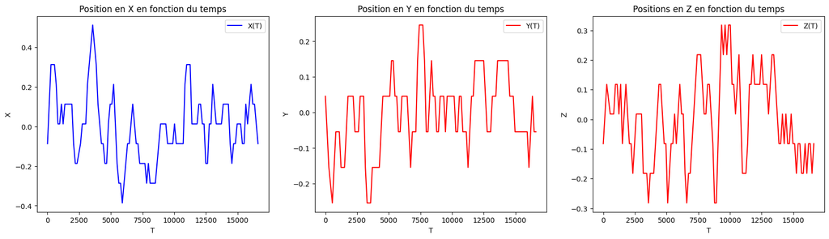

```python
X_mean = np.mean(X)
Y_mean = np.mean(Y)
Z_mean = np.mean(Z)

# Créer une figure et deux sous-graphiques
fig, (ax1, ax2,ax3) = plt.subplots(ncols=3, figsize=(20, 5))

# Tracer le premier graphique sur le premier sous-graphique
ax1.plot(T, X - X_mean, color='blue', label='X(T)')
ax1.set_xlabel('T')
ax1.set_ylabel('X')
ax1.set_title('Position en X en fonction du temps')
ax1.legend()

# Tracer le deuxième graphique sur le deuxième sous-graphique
ax2.plot(T, Y - Y_mean, color='red', label='Y(T)')
ax2.set_xlabel('T')
ax2.set_ylabel('Y')
ax2.set_title('Position en Y en fonction du temps')
ax2.legend()

# Tracer le troisième graphique sur le troisième sous-graphique
ax3.plot(T, Z - Z_mean, color='red', label='Z(T)')
ax3.set_xlabel('T')
ax3.set_ylabel('Z')
ax3.set_title('Positions en Z en fonction du temps')
ax3.legend()

# Afficher la figure
plt.show()
```

On constate que les positions varient dans un intervalle de l'ordre du centimètre. On va maintenant estimer la variance de ces données.

```python
# Calcul de l'écart type des données
X_std = np.std(X)
Y_std = np.std(Y)
Z_std = np.std(Z)

# Calcul de la variance des données
X_var = np.var(X)
Y_var = np.var(Y)
Z_var = np.var(Z)

# Affichage des résultats
print("Ecart type de X :", X_std)
print("Variance de X :", X_var ,  "\n")

print("Ecart type de Y :", Y_std)
print("Variance de Y :", Y_var, "\n")

print("Ecart type de Z :", Z_std)
print("Variance de Z :", Z_var)
```

```
Ecart type de X : 0.16799578313430077
Variance de X : 0.02822258315090702

Ecart type de Y : 0.10670614574353597
Variance de Y : 0.011386201539440739

Ecart type de Z : 0.14415622875779094
Variance de Z : 0.02078101828966855
```

On constate donc une variance de l'ordre du millimètre sur nos données. Cette mesure admet cependant une limite car elle est faite dans un cadre statique, il pourrait également être utile d'estimer la variance dans un contexte ou le marvelmind est mobile.

#### II.b.2 - Odométrie

Quant à la variance des données d'odométrie, on la considérera comme plus grande que celle des données Marvelmind, sa valeur reste encore à définir.

Le phénomène de dérive peut également se produire en raison de l'accumulation d'erreurs systématiques dans le temps. Même de petites erreurs initiales peuvent s'accumuler progressivement et entraîner une dérive importante du système. Pour calculer la dérive, on va faire faire un long parcours au train sur un trajet dont on connait la distance, afin de comparer la distance affichée par l'odométrie à la distance réelle, et eventuellement recalibrer le signal d'odométrie.

## III - Mise en place

On travaille ici sur un échantillon de données correspondant au mouvement du train faisant un tour le long de la boucle extérieure de l'infrastructure. On va simuler un filtre de Kalman le long d'une ligne droite sur le parcours du train.

### III.a - Preprocessing des données

#### III.a.1 - Marvelmind

De même que lors du calcul de variance, on mets l'ensemble de nos données en cm. On doit aussi recalibrer nos deux signaux pour qu'ils correpondent au même temps, car ils ont un léger décalage temporel.

On devra aussi vérifier que l'odométrie est bien calibrée, en vérifiant si la dérive n'est pas trop grande, en comparant la distance obtenue via marvelmind avec celle obtenue via odométrie.

```python
f = open("./data/test_parcours_train_3_marvelmind.txt", "r") # Lecture du document et mise sous forme de matrice
lines=f.readlines()

X_marvelmind = []
Y_marvelmind = []
Z_marvelmind = []
T_marvelmind = []


count_lines = 0
t_0 = int(lines[4].split(',')[5].strip().split(': ')[2])

for line in lines:
    if count_lines > 3:
        parts = line.split(',')
        x_val = float(parts[1].strip().split(': ')[1])
        y_val = float(parts[2].strip().split(': ')[1])
        z_val = float(parts[3].strip().split(': ')[1])
        t_val = int(parts[5].strip().split(': ')[2])
        #On obtient les données en centimètres
        X_marvelmind.append(x_val*100)
        Y_marvelmind.append(-y_val*100)
        Z_marvelmind.append(z_val*100)
        T_marvelmind.append(t_val - t_0) #On part de t = 0
    count_lines = count_lines + 1
print(len(T_marvelmind))
```

```
340
```

On affiche ensuite la trajectoire du train dans l'infrastructure.

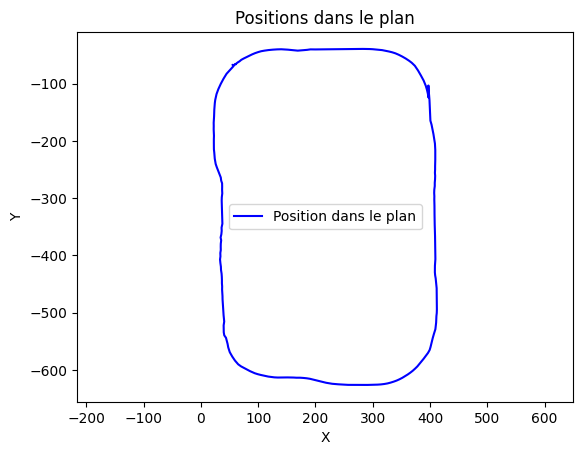

```python
plt.plot(X_marvelmind, Y_marvelmind, color='blue', label='Position dans le plan')
plt.xlabel('X')
plt.ylabel('Y')
plt.title('Positions dans le plan')
plt.axis('equal')
plt.legend()
```

On calcule ici la distance totale parcourue par le train d'après le Marvelmind.

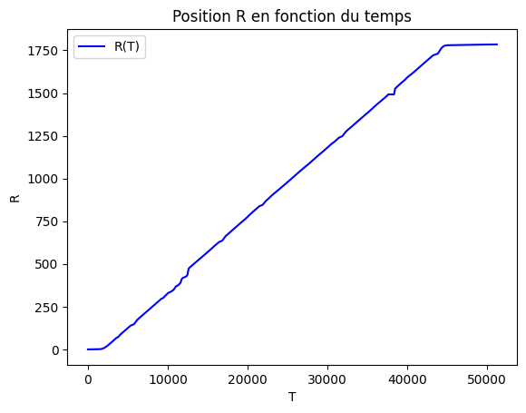

```python
def distance_euclidienne(x1,y1, x2, y2):
    return np.sqrt(np.power(x1 - x2,2) + np.power(y1 - y2,2))

distance_parcourue_marvelmind = [0]
for i in range(1,len(T_marvelmind)):
    distance_parcourue_marvelmind.append(distance_euclidienne(X_marvelmind[i], Y_marvelmind[i], X_marvelmind[i-1], Y_marvelmind[i-1]) + distance_parcourue_marvelmind[i-1])

plt.plot(T_marvelmind,distance_parcourue_marvelmind, color='blue', label='R(T)')
plt.xlabel('T')
plt.ylabel('R')
plt.title('Position R en fonction du temps')
plt.legend()

# Afficher la figure
plt.show()
```

```python
print(distance_parcourue_marvelmind[-1])
```

```
1784.6693985427214
```

Le marvelmind nous indique que l'on a effectué un trajet d'une longueur d'à peu près 1750cm.

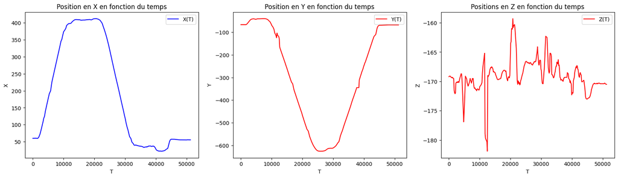

```python
# Créer une figure et deux sous-graphiques
fig, (ax1, ax2,ax3) = plt.subplots(ncols=3, figsize=(20, 5))

# Tracer le premier graphique sur le premier sous-graphique
ax1.plot(T_marvelmind, X_marvelmind, color='blue', label='X(T)')
ax1.set_xlabel('T')
ax1.set_ylabel('X')
ax1.set_title('Position en X en fonction du temps')
ax1.legend()

# Tracer le deuxième graphique sur le deuxième sous-graphique
ax2.plot(T_marvelmind, Y_marvelmind, color='red', label='Y(T)')
ax2.set_xlabel('T')
ax2.set_ylabel('Y')
ax2.set_title('Position en Y en fonction du temps')
ax2.legend()

# Tracer le troisième graphique sur le troisième sous-graphique
ax3.plot(T_marvelmind, Z_marvelmind, color='red', label='Z(T)')
ax3.set_xlabel('T')
ax3.set_ylabel('Z')
ax3.set_title('Positions en Z en fonction du temps')
ax3.legend()

# Afficher la figure
plt.show()
```

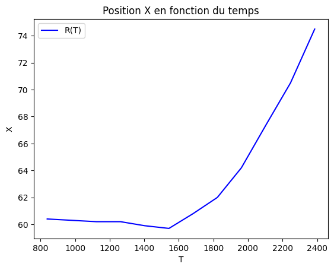

```python
plt.plot(T_marvelmind[6:18],X_marvelmind[6:18], color='blue', label='R(T)')
plt.xlabel('T')
plt.ylabel('X')
plt.title('Position X en fonction du temps')
plt.legend()

# Afficher la figure
plt.show()
```

```python
print(X_marvelmind[6:18])
```

```
[60.4, 60.3, 60.199999999999996, 60.199999999999996, 59.9, 59.699999999999996, 60.8, 62.0, 64.2, 67.4, 70.5, 74.5]
```

```python
print("T[13] = " + str(T_marvelmind[13]) + " et X[13] = " + str(X_marvelmind[13]))
```

```
T[13] = 1823 et X[13] = 62.0
```

On voit bien ici que le train commence son parcours après environ 1800 millisecondes. On recalibre notre signal pour qu'il commence quand le train commence son parcours.

```python
X_marvelmind_2 = []
Y_marvelmind_2 = []
Z_marvelmind_2 = []
T_marvelmind_2 = []
for i in range(len(T_marvelmind[13:])):
    T_marvelmind_2.append(T_marvelmind[13+i])
    X_marvelmind_2.append(X_marvelmind[13+i])
    Y_marvelmind_2.append(Y_marvelmind[13+i])
    Z_marvelmind_2.append(Z_marvelmind[13+i])
```

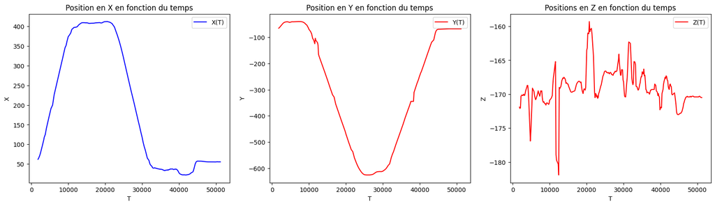

```python
# Créer une figure et deux sous-graphiques
fig, (ax1, ax2,ax3) = plt.subplots(ncols=3, figsize=(20, 5))

# Tracer le premier graphique sur le premier sous-graphique
ax1.plot(T_marvelmind_2, X_marvelmind_2, color='blue', label='X(T)')
ax1.set_xlabel('T')
ax1.set_ylabel('X')
ax1.set_title('Position en X en fonction du temps')
ax1.legend()

# Tracer le deuxième graphique sur le deuxième sous-graphique
ax2.plot(T_marvelmind_2, Y_marvelmind_2, color='red', label='Y(T)')
ax2.set_xlabel('T')
ax2.set_ylabel('Y')
ax2.set_title('Position en Y en fonction du temps')
ax2.legend()

# Tracer le troisième graphique sur le troisième sous-graphique
ax3.plot(T_marvelmind_2, Z_marvelmind_2, color='red', label='Z(T)')
ax3.set_xlabel('T')
ax3.set_ylabel('Z')
ax3.set_title('Positions en Z en fonction du temps')
ax3.legend()

# Afficher la figure
plt.show()
```

On a bien recalibré notre signal.

On fait maintenant un parsing et un affichage des données d'odométrie.

#### III.a.2 - Odometrie

```python
f = open("./data/test_parcours_train_3_odometrie.txt", "r") # Lecture du document et mise sous forme de matrice
lines=f.readlines()

R_odometrie = []
T_odometrie = []

first_value = lines[0].split(',')
t_0 =  int(first_value[2].split(':')[0]) * 1000000000 + int(first_value[2].split(':')[1])


for i in range(len(lines)-5):
    values = lines[i].split(',')
    R_odometrie.append(float(values[0]))
    #print(int(values[2].split(':')[1]))
    T_odometrie.append(int(int(values[2].split(':')[0]) * 1000000000 + int(values[2].split(':')[1]) - t_0)/1000000)

print("Nombre de données de position et vitesse = " + str(len(R_odometrie)))
```

```
Nombre de données de position et vitesse = 1945
```

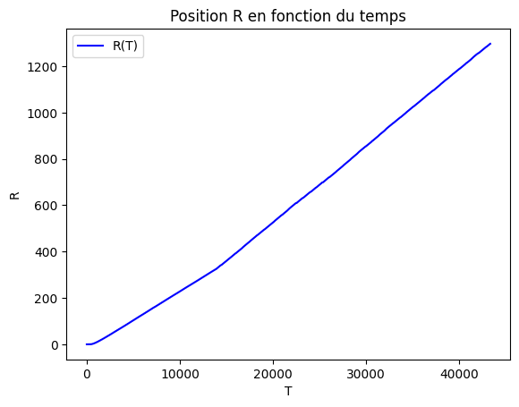

```python
plt.plot(T_odometrie,R_odometrie, color='blue', label='R(T)')
plt.xlabel('T')
plt.ylabel('R')
plt.title('Position R en fonction du temps')
plt.legend()

# Afficher la figure
plt.show()
```

```python
print(R_odometrie[-1])
```

```
1296.927612
```

```python
coefficient_odometrie_marvelmind = R_odometrie[-1]/distance_parcourue_marvelmind[-1]
print("Facteur de distance entre les données d'odométrie et marvelmind:" + str(coefficient_odometrie_marvelmind) )
```

```
Facteur de distance entre les données d'odométrie et marvelmind:0.7267046843852487
```

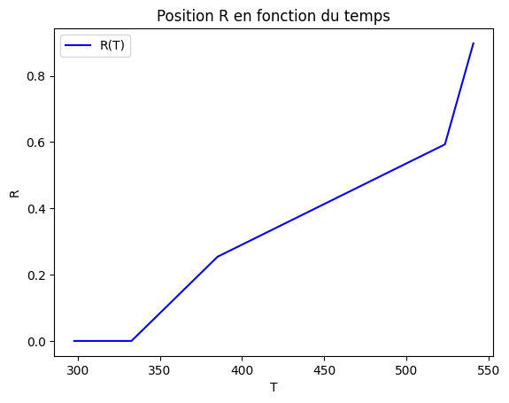

```python
plt.plot(T_odometrie[10:20],R_odometrie[10:20], color='blue', label='R(T)')
plt.xlabel('T')
plt.ylabel('R')
plt.title('Position R en fonction du temps')
plt.legend()

# Afficher la figure
plt.show()
```

```python
print(R_odometrie[10:20])
```

```
[0.0, 0.0, 0.08472, 0.16944, 0.25416, 0.33888, 0.4236, 0.50832, 0.59304, 0.898032]
```

```python
print("T[12] = " + str(T_odometrie[12]) + " et R[12] = " + str(R_odometrie[12]))
```

```
T[12] = 350.249997 et R[12] = 0.08472
```

```python
#On recalibre temporellement et on limite la dérive
R_odometrie_2 = []
T_odometrie_2 = []
for i in range(len(T_odometrie[12:])):
    R_odometrie_2.append(R_odometrie[12+i]/coefficient_odometrie_marvelmind)
    T_odometrie_2.append(T_odometrie[12+i])
```

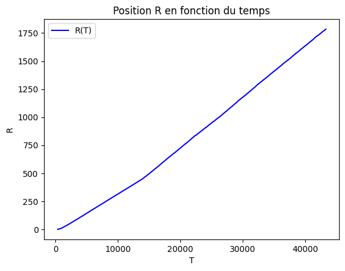

```python
plt.plot(T_odometrie_2,R_odometrie_2, color='blue', label='R(T)')
plt.xlabel('T')
plt.ylabel('R')
plt.title('Position R en fonction du temps')
plt.legend()

# Afficher la figure
plt.show()
```

```python
R_preprocessed_2 = []

for i in range(len(T_marvelmind_2)):
    for k in range(len(T_odometrie_2)):
        if T_odometrie_2[k] > T_marvelmind_2[i]:
            R_preprocessed_2.append(R_odometrie_2[k])
            break

T_marvelmind_2 = T_marvelmind_2[:len(R_preprocessed_2)]
Y_marvelmind_2 = Y_marvelmind_2[:len(R_preprocessed_2)]
X_marvelmind_2 = X_marvelmind_2[:len(R_preprocessed_2)]
```

On a finalement nos deux signaux à des temps égaux.

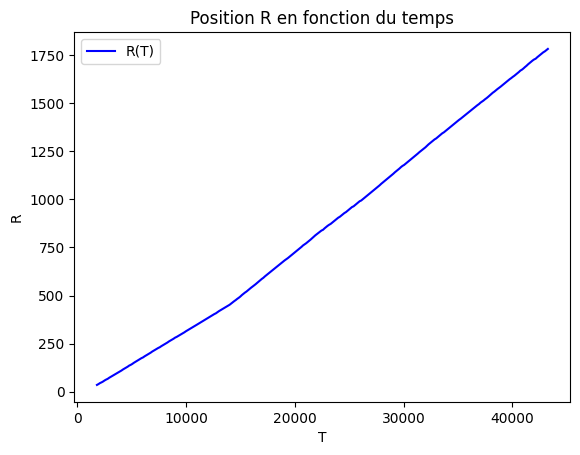

```python
plt.plot(T_marvelmind_2,R_preprocessed_2, color='blue', label='R(T)')
plt.xlabel('T')
plt.ylabel('R')
plt.title('Position R en fonction du temps')
plt.legend()

# Afficher la figure
plt.show()
```

### III.b - Implémentation du filtre de Kalman

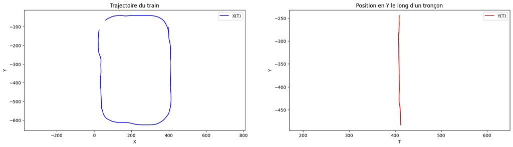

```python
# Créer une figure et deux sous-graphiques
fig, (ax1, ax2) = plt.subplots(ncols=2, figsize=(20, 5))

# Tracer le premier graphique sur le premier sous-graphique
ax1.plot(X_marvelmind_2, Y_marvelmind_2, color='blue', label='X(T)')
ax1.set_xlabel('X')
ax1.set_ylabel('Y')
ax1.set_title('Trajectoire du train')
ax1.legend()
ax1.axis('equal')

# Tracer le deuxième graphique sur le deuxième sous-graphique
ax2.plot(X_marvelmind_2[80:120], Y_marvelmind_2[80:120], color='red', label='Y(T)')
ax2.set_xlabel('T')
ax2.set_ylabel('Y')
ax2.set_title('Position en Y le long d\'un tronçon')
ax2.legend()
ax2.axis('equal')


# Afficher la figure
plt.show()
```

```python
Y_marvelmind_troncon = []
R_odometrie_troncon = []

Y_initial = - Y_marvelmind_2[80]
R_initial = R_preprocessed_2[80]

for i in range(len(Y_marvelmind_2[80:120])):
    Y_marvelmind_troncon.append(- Y_marvelmind_2[80 + i] - Y_initial)
    R_odometrie_troncon.append(R_preprocessed_2[80 +i] - R_initial)
```

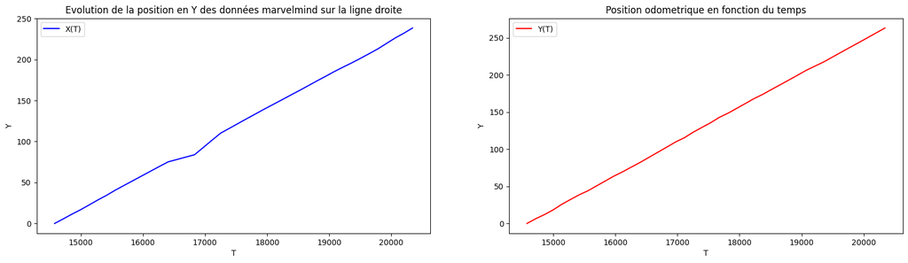

```python
# Créer une figure et deux sous-graphiques
fig, (ax1, ax2) = plt.subplots(ncols=2, figsize=(20, 5))

# Tracer le premier graphique sur le premier sous-graphique
ax1.plot(T_marvelmind_2[80:120], Y_marvelmind_troncon, color='blue', label='X(T)')
ax1.set_xlabel('T')
ax1.set_ylabel('Y')
ax1.set_title('Evolution de la position en Y des données marvelmind sur la ligne droite')
ax1.legend()

# Tracer le deuxième graphique sur le deuxième sous-graphique
ax2.plot(T_marvelmind_2[80:120], R_odometrie_troncon, color='red', label='Y(T)')
ax2.set_xlabel('T')
ax2.set_ylabel('Y')
ax2.set_title('Position odometrique en fonction du temps')
ax2.legend()


# Afficher la figure
plt.show()
```

[output not shown]

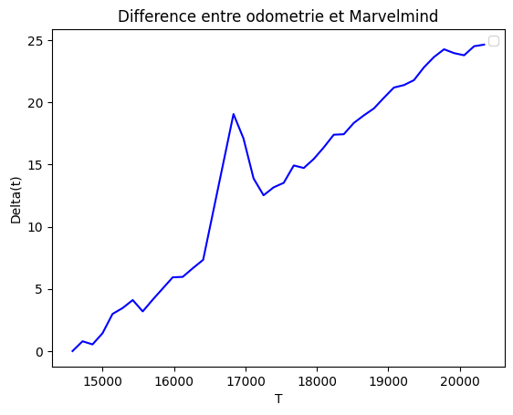

```python
difference_odometrie_marvelmind = []

for i in range(len(R_odometrie_troncon)):
    difference_odometrie_marvelmind.append(R_odometrie_troncon[i] - Y_marvelmind_troncon[i])

plt.plot(T_marvelmind_2[80:120],difference_odometrie_marvelmind, color='blue')
plt.xlabel('T')
plt.ylabel('Delta(t)')
plt.title('Difference entre odometrie et Marvelmind')
plt.legend()

# Afficher la figure
plt.show()
```

On constate qu'il y a un phénomène de dérive malgré la calibration de l'odométrie faite précédemment. On recalibrera plus tard l'odométrie avec plus de données.

On peut maintenant implémenter le filtre de Kalman. Voici les paramètres obtenus via les différentes analyses de données. Tout d'abord R qui correspond aux bruits de mesure des différents capteurs.

où $\sigma_{marvelmind}^2$ représente la variance des données marvelmind, $\sigma_{odometrie}^2$ représente la variance des données d'odométrie.

Q qui correspond aux incertitudes sur le modèle. On la prend pour l'instant arbitrairement égale à identité.

$$ Q =\begin{bmatrix} 1 & 0 \\ 0 & 1 \end{bmatrix}$$

On sait que le système réagit à une commande en vitesse de 40cm/s et est en régime stable lorsque l'on effectue notre fusion de données, on a donc un état initial:

$$ x_0 = \begin{bmatrix} 0 \\ 40 \end{bmatrix}$$

Avec $P_0$ choisi de manière arbitraire.

```python
#Etat initial
v_0 = 40 #en cm/s

x_0 = np.array([[0],[v_0]])
P_0 = np.array([[1,0],[1,0]]) #Qu'on prend arbitrairement à identité

#Matrices de bruit
Q = np.array([[1,0],[0,1]]) #Qu'on prend arbitrairement à identité
R = np.array([[1,0],[0,10]])
```

```python
def predict(x_k, P_k, u_k):
    A_transpose = A.T
    return [A.dot(x_k)+ B.dot(0.01*u_k), A.dot(P_k).dot(A_transpose) + Q]

def correct(x_k_minus, P_k_minus, z_k):
    K_k = P_k_minus.dot(H.T).dot( np.linalg.inv(H.dot(P_k_minus).dot(H.T) + R) )
    x_k = x_k_minus + K_k.dot(z_k - H.dot(x_k_minus))
    P_k = (np.eye(2) - K_k.dot(H)).dot(P_k_minus)
    return([x_k, P_k])
```

```python
T_troncon = T_marvelmind_2[80:120]

state_corrected = []

prediction = []
correction = []
x_k = x_0
P_k = P_0
u_k = 40 #Consigne de 40 cm/s
for k in range(len(T_troncon)-1):
    prediction = predict(x_k, P_k, u_k )

    x_k_minus = prediction[0]
    P_k_minus = prediction[1]

    z_k = np.array([[Y_marvelmind_troncon[k+1]], [R_odometrie_troncon[k+1]]])

    correction = correct(x_k_minus, P_k_minus, z_k)
    x_k = correction[0]
    P_k = correction[1]
    state_corrected.append(x_k)
```

```python
R_corrected = [0]
V_corrected = [v_0]

for i in state_corrected:
    R_corrected.append(i[0][0])
    V_corrected.append(i[1][0])
```

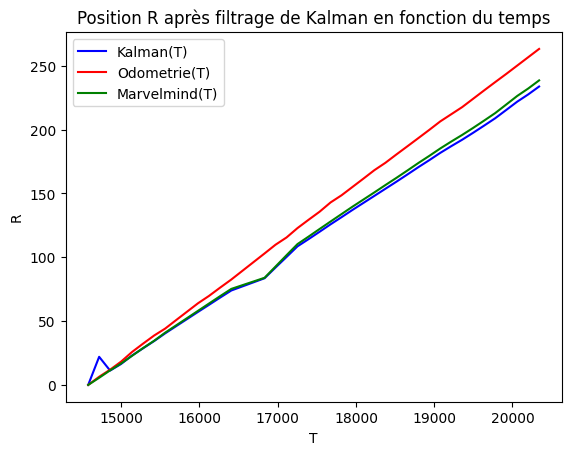

```python
plt.plot(T_troncon,R_corrected, color='blue', label='Kalman(T)')
plt.plot(T_troncon,R_odometrie_troncon, color='red', label='Odometrie(T)')
plt.plot(T_troncon,Y_marvelmind_troncon, color='green', label='Marvelmind(T)')

plt.xlabel('T')
plt.ylabel('R')
plt.title('Position R après filtrage de Kalman en fonction du temps')
plt.legend()

# Afficher la figure
plt.show()
```

### III.c - Analyse des résultats

On va mettre en place le même filtre que précédemment sur nos données, mais en faisant varier la matrice Q et la matrice R afin de visualiser leur effet sur le filtre.